# TwitteR: introductory session

Mik Black

2 August 2016

This material covers a VERY basic introduction to some of the functionality provided by the `twitteR` package for R.

It borrows heavily from multiple sources:

- https://github.com/pablobarbera/social-media-workshop
- http://www.rdatamining.com/docs/r-and-data-mining-examples-and-case-studies
- http://www.r-bloggers.com/playing-with-twitter-data/

### R libraries

The main R package used during this session is `twitteR`. You can install this via:

```r
install.packages("twitteR", repos="http://cran.stat.auckland.ac.nz")
```

We’ll also need the `tm` package for part of the session:

```r
install.packages("tm", repos="http://cran.stat.auckland.ac.nz")
```

### Getting started

In order to use the Twitter API* to gather data, you need to create a “Twitter app” (you also need a Twitter account). This process generates an authentication tiken that can be used from within R to gain access to tweet data via the API.

- Step 1: go to apps.twitter.com and sign in
- Step 2: click on “Create New App”
- Step 3: fill name, description, and website (it can be any website): make sure you leave ‘Callback URL’ empty.
- Step 4: agree to user conditions
- Step 5: get key and token information from “Keys and Access Tokens” tab: copy these and paste them into the R code below.

*API = Application program interface: “set of routine definitions, protocols, and tools for building software and applications. A good API makes it easier to develop a program by providing all the building blocks, which are then put together by the programmer”: https://en.wikipedia.org/wiki/Application_programming_interface

### Using the token info in R

```r
consumerKey = "XXXXXXXXXXXX"
consumerSecret = "YYYYYYYYYYYYYYYYYYY"
accessToken = "ZZZZZZZZZZZZZZ"
accessSecret = "AAAAAAAAAAAAAAAAAA"

library(twitteR)
setup_twitter_oauth(consumer_key=consumerKey, consumer_secret=consumerSecret,
            access_token=accessToken, access_secret=accessSecret)
```

### Using the twitteR package

The first step is to send the authentication information to twitter.

Alternatively, you can load the `.RData` file below to load the tweet data that I have already downloaded - that will save you going through the app creation process just to reproduce the results below.

If you want to skip the app creation, and just loading the existing tweet data, uncomment and run the following:

```r
## load('tweetData.RData)
```

You can then skip ahead to “Examining a twitter timeline” below. Otherwise, continue with the following…

**NB: I’m assuming that we are starting from this point, and the code above hasn’t yet been run.**

```r
rm(list=ls())
library(twitteR)

## Enter your key/token info below
consumerKey = "XXXXXXXXXXXX"
consumerSecret = "YYYYYYYYYYYYYYYYYYY"
accessToken = "ZZZZZZZZZZZZZZ"
accessSecret = "AAAAAAAAAAAAAAAAAA"

## Alternative: save key/token info to separate file
source('myKeyData.R')

## Authenticate with Twitter
setup_twitter_oauth(consumer_key=consumerKey, consumer_secret=consumerSecret,
                    access_token=accessToken, access_secret=accessSecret)
```

```
## [1] "Using direct authentication"
```

Once the token information is set up, it can be used to query timeline data via the twitter API. Let’s make a basic query to retrieve the last tweet that mentioned the word “highlanders”.

```r
searchTwitter('highlanders', n=1)
```

```
## [[1]]
## [1] "burksclaudine1: RT @IAFFLocal5: Thanks to Pikes Peak Highlanders and Colorado Springs Police Department for the help from their members!... https://t.co/sC…"
```

### Examining a twitter timeline

Retrieve the last 20 tweets from the NZ Prime Minister

```r
keyTweets <- userTimeline("johnkeypm", n=20)
```

How many did we get?

```r
length(keyTweets)
```

```
## [1] 20
```

Lets look at the first few (most recent)

```r
head(keyTweets)
```

```
## [[1]]
## [1] "johnkeypm: We've made changes to HomeStart to help even more Kiwis into their first home.\nhttps://t.co/H1GdcRV3wB"
##
## [[2]]
## [1] "johnkeypm: We’re making changes to help more Kiwis into their first home with a HomeStart grant.\nhttps://t.co/PoV5SUjVwq"
##
## [[3]]
## [1] "johnkeypm: Welcomed Tongan Prime Minister Samuela ‘Akilisi Pohiva to Auckland this afternoon - his first official visit as PM. https://t.co/5wcxfmT4p1"
##
## [[4]]
## [1] "johnkeypm: Dropped into Sky Kiwi for an interview – and a selfie. https://t.co/3zWyjz2Dnq"
##
## [[5]]
## [1] "johnkeypm: On WTV with Dr Jian Yang talking about Auckland's Unitary Plan and the importance of NZ's relationship with China. https://t.co/9z9MXbWrau"
##
## [[6]]
## [1] "johnkeypm: Exciting to open David Jones' first New Zealand store in Wellington tonight. https://t.co/JJiYMH3pJE"
```

What type of objects are we dealing with?

```r
class(keyTweets)
```

```
## [1] "list"
```

```r
class(keyTweets[[1]])
```

```
## [1] "status"
## attr(,"package")
## [1] "twitteR"
```

The tweets are a list of “status” objects that are specific to the twitteR package. What else can we find out about these?

```r
## Below is equivalent to: getClass("status")
getClass(class(keyTweets[[1]]))
```

```
## Reference Class "status":
##
## Class fields:
##
## Name:           text     favorited favoriteCount     replyToSN
## Class:     character       logical       numeric     character
##
## Name:        created     truncated    replyToSID            id
## Class:       POSIXct       logical     character     character
##
## Name:     replyToUID  statusSource    screenName  retweetCount
## Class:     character     character     character       numeric
##
## Name:      isRetweet     retweeted     longitude      latitude
## Class:       logical       logical     character     character
##
## Name:           urls
## Class:    data.frame
##
## Class Methods:
##      "setUrls", "getRetweets", "getRefClass", "getUrls", "setTruncated",
##      "setText", "getReplyToSID", "getText", "export", "setCreated",
##      "setFavoriteCount", "getCreated", "initialize", "callSuper",
##      "getRetweeters", "initFields", "getClass", "setReplyToUID", "import",
##      "setLatitude", "setIsRetweet", "getFavoriteCount", "getRetweetCount",
##      "getIsRetweet", "setId", "setScreenName", "getLatitude",
##      "getScreenName", "toDataFrame#twitterObj", "setRetweetCount",
##      "setReplyToSID", "getId", "getReplyToUID", "setFavorited",
##      "getRetweeted", "getFavorited", "toDataFrame", "setStatusSource",
##      "setReplyToSN", "copy", "usingMethods", "setRetweeted", "field",
##      ".objectParent", "getTruncated", "untrace", "trace", "setLongitude",
##      "getLongitude", "getStatusSource", ".objectPackage", "getReplyToSN",
##      "show"
##
## Reference Superclasses:
##      "twitterObj", "envRefClass"
```

There are a lot of additional fields of information available for each tweet:

```r
## Display the text of the first tweet
keyTweets[[1]]$text
```

```
## [1] "We've made changes to HomeStart to help even more Kiwis into their first home.\nhttps://t.co/H1GdcRV3wB"
```

```r
## Display the time of the first tweet
keyTweets[[1]]$created
```

```
## [1] "2016-08-02 02:03:21 UTC"
```

In order to make access to these fields easier, `twitteR` provides a function to convert the list of tweets into a data frame:

```r
## Convert to data frame
keyTweetsDf <- twListToDF(keyTweets)

## Check dimensions
dim(keyTweetsDf)
```

```
## [1] 20 16
```

```r
## Examine first row (most recent tweet)
keyTweetsDf[1,]
```

```
##                                                                                                      text
## 1 We've made changes to HomeStart to help even more Kiwis into their first home.\nhttps://t.co/H1GdcRV3wB
##   favorited favoriteCount replyToSN             created truncated
## 1     FALSE             9        NA 2016-08-02 02:03:21     FALSE
##   replyToSID                 id replyToUID
## 1         NA 760294886457298944         NA
##                                                                          statusSource
## 1 <a href="https://about.twitter.com/products/tweetdeck" rel="nofollow">TweetDeck</a>
##   screenName retweetCount isRetweet retweeted longitude latitude
## 1  johnkeypm            6     FALSE     FALSE        NA       NA
```

### Sentiment analysis

The idea of “sentiment analysis” can be used to assess the sentiment (e.g., positive or negative) of a tweet.

There are a few ways to do this (using additional packages), but we are going to use a “first principles” approach, as taken in this workshop:

https://github.com/pablobarbera/social-media-workshop

First, lets load a data set of positive and negative words:

```r
# loading lexicon of positive and negative words (from Github repo above)
lexicon <- read.csv("lexicon.csv", stringsAsFactors=F)
pos.words <- lexicon$word[lexicon$polarity=="positive"]
neg.words <- lexicon$word[lexicon$polarity=="negative"]

# a look at a random sample of positive and negative words
sample(pos.words, 10)
```

```
##  [1] "affability"   "informative"  "sparkling"    "epic"
##  [5] "mercy"        "decisiveness" "endorsement"  "above"
##  [9] "overture"     "survival"
```

```r
sample(neg.words, 10)
```

```
##  [1] "refutation" "excuse"     "worries"    "goddamn"    "freak"
##  [6] "delusion"   "oppressive" "abhors"     "vileness"   "manic"
```

NB: if you are having trouble downloading the `lexicon.csv` file from GitHub, you can read it in directly by uncommenting and running the following code:

```r
## lexicon <- read.csv("https://raw.githubusercontent.com/mikblack/twitteR-intro/master/lexicon.csv", stringsAsFactors=F)
```

Next we’ll load some helper functions (again, courtesy of the Github repo above) to handle the processing of the tweet data:

```r
## Load helper functions
source('twitteR-intro-helper-functions.R')
```

The functions are:

- `clean_tweets`: split each tweet into individual words, and remove special characters.
- `classify`: score the overall “positivity” or “negativity” of a tweet, based on the numbers of positive and negative words it contains.
- `classifer`: applies the `classify` function to a collection of tweets, and returns aggregated statistics.

Before we get started on our sentiment analysis, let’s generate some more data:

```r
## Retrieve tweet data for Obama, Trump and Clinton.
obamaTweets <- userTimeline("BarackObama", n=3200)
trumpTweets <- userTimeline("realDonaldTrump", n=3200)
clintonTweets <- userTimeline("HillaryClinton", n=3200)
```

```r
## Check lengths
length(obamaTweets)
```

```
## [1] 373
```

```r
length(trumpTweets)
```

```
## [1] 1616
```

```r
length(clintonTweets)
```

```
## [1] 259
```

```r
## Convert each list to a data frame
obamaDf <- twListToDF(obamaTweets)
trumpDf <- twListToDF(trumpTweets)
clintonDf <- twListToDF(clintonTweets)
```

Now apply the helper fuctions to our data.

```r
## Clean tweets
obamaText <- clean_tweets(obamaDf$text)
trumpText <- clean_tweets(trumpDf$text)
clintonText <- clean_tweets(clintonDf$text)
```

What did that do?

```r
## Original tweet
obamaDf$text[1]
```

```
## [1] "Judge Garland should get a fair hearing and an up-or-down vote from the Senate. Speak out. https://t.co/7pWxq5J2DO #DoYourJob"
```

```r
## Clean tweet
obamaText[1]
```

```
## [[1]]
##  [1] "judge"              "garland"            "should"
##  [4] "get"                "a"                  "fair"
##  [7] "hearing"            "and"                "an"
## [10] "upordown"           "vote"               "from"
## [13] "the"                "senate"             "speak"
## [16] "out"                "httpstco7pwxq5j2do" "doyourjob"
```

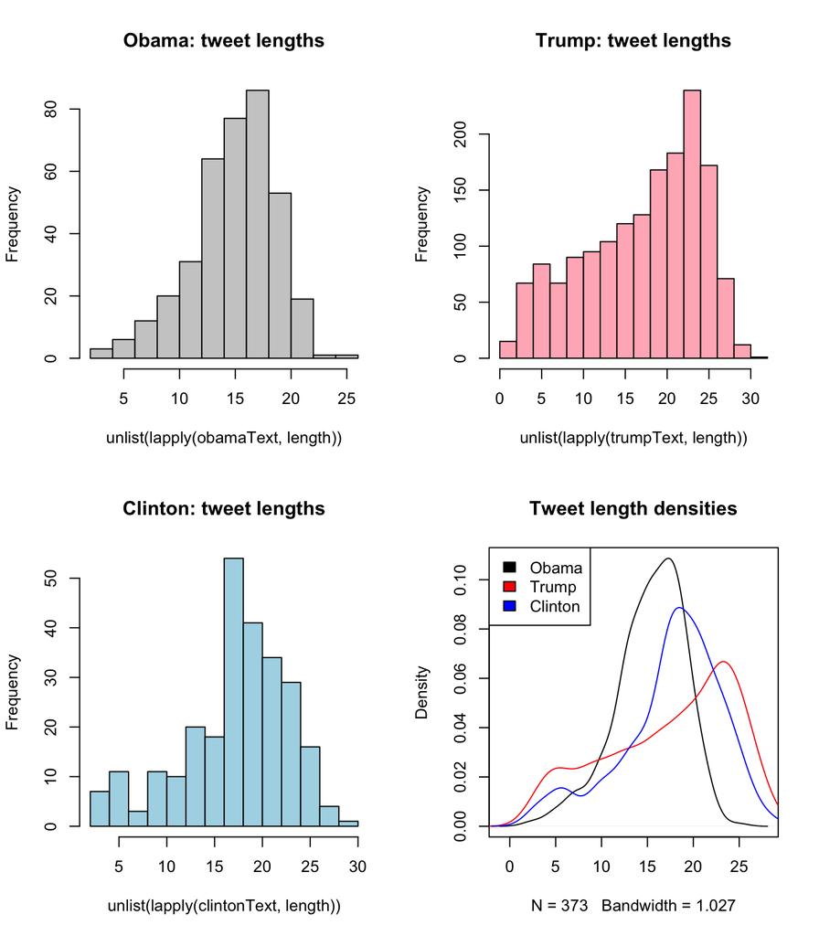

```r
par(mfrow=c(2,2))
## Histograms of tweet length
hist(unlist(lapply(obamaText,length)), col=grey(0.8), main="Obama: tweet lengths")
hist(unlist(lapply(trumpText,length)), col='lightpink', main="Trump: tweet lengths")
hist(unlist(lapply(clintonText,length)), col='lightblue', main="Clinton: tweet lengths")

## Tweet length density plots
plot(density(unlist(lapply(obamaText,length))), main="Tweet length densities")
lines(density(unlist(lapply(trumpText,length))), col='red')
lines(density(unlist(lapply(clintonText,length))), col='blue')
legend('topleft', c("Obama","Trump","Clinton"), fill=c("black", "red", "blue"))
```

### Sentiment analysis

Use the `classify` function to assess the positive/negative content of a tweet:

```r
classify(obamaText[[1]], pos.words, neg.words)
```

```
## [1] 1
```

Apply to all tweets (for once I won’t use `lapply`…):

```r
## Calculate scores for every Obama tweet
obamaScore <- c()
for(i in 1:length(obamaText)){
  obamaScore[i] <- classify(obamaText[[i]], pos.words, neg.words)
}
## Display scores
obamaScore
```

```
##   [1]  1  2  2  0  0  2  0 -1  0 -1  1  2 -3  2 -1  1  0  1  1  1  0  2 -1
##  [24]  0 -2 -1  1 -1 -1  2 -1  2  0  2  1  1  0  1  0  1  1 -1  0  1  0  0
##  [47]  0  0  0  1  1  2  0  1  1  0  1  0 -3  0  0  0 -1  1  0  1  0  0  1
##  [70]  1  0  2  1  1  1  0 -1  1  2  3  2  1  1  2  0  3  1  1  1  1  0  0
##  [93] -1  1  1  1  0  0  1  1 -1  0  0  1  0 -2 -2  2  1  4  1  3  0  0  0
## [116]  1  2  0  0  1  0  0  0  0  0  0  0  1 -1  0  1  2  0  1  0  0  0  1
## [139] -1 -1  1 -1  2  0  2  2  0 -1  0  2  0  0  0  1  0  2  0  1  0  1  1
## [162]  0  1  1  0 -2  0  0  2  1  3  2  2  0  1  1  2  0  0  0  1  0  1  1
## [185]  0  1  0  0  0  1  0  1  1  2  1  1  1  2  0  0  1  0  1  0  0  1 -1
## [208]  1  0  0  1  1  1  0  0  2  0 -1  2 -1  2  0 -2  2  0 -2  0  0  1  0
## [231]  1  0  2  4  1  1  0  0  2  1  2  0  1  0  1  1  1  0  1  2  1  0  2
## [254]  0  1  0  3  1  2  0  1  1  1  3  0  0  0  0  1  0  3  0  0  1  0  1
## [277]  1  2  2  1  0  1  1  1  1  2  2  3  2  1  1  0 -1  1  1  1  0  2  2
## [300]  0  1 -1 -1  0  2  0  1  0  2  2  2  2  1  2  0  0  2  1  1  1 -1  1
## [323]  1 -1  2  1  1 -1  0  1  2  2  1  0  0  1  0  0  0  0  1  1  0  1  0
## [346]  0  0  0 -1  0  1  0  1  0  1  1  0  1  2  1  0  1  1  0  0  0  0  0
## [369]  2  1  1  0  0
```

```r
## What was the range of scores?
range(obamaScore)
```

```
## [1] -3  4
```

```r
## Which was the highest score?
which.max(obamaScore)
```

```
## [1] 110
```

```r
## What was that tweet?
obamaTweets[[which.max(obamaScore)]]
```

```
## [1] "BarackObama: Your support for a fair hearing and timely up-or-down vote to fill the vacancy on the Supreme Court matters: https://t.co/qfpOoUefet"
```

```r
## Which was the lowest score?
which.min(obamaScore)
```

```
## [1] 13
```

```r
## What was that tweet?
obamaTweets[[which.min(obamaScore)]]
```

```
## [1] "BarackObama: Wildfire seasons are getting longer, more dangerous, and more expensive. We need to do more to #ActOnClimate. https://t.co/hpHjwknx3v"
```

Sentiment analysis seems to be an inexact art…

**Challenge: what were Donald Trump’s most positive and most negative tweets?**

### Sentiment analysis: final task

Apply the `classifier` function to aggregate scores across all tweets for each user.

```r
# applying classifier function
classifier(obamaText, pos.words, neg.words)
```

```
## 373 tweets: 52 % positive, 9 % negative, 39 % neutral
```

```r
classifier(trumpText, pos.words, neg.words)
```

```
## 1616 tweets: 41 % positive, 25 % negative, 34 % neutral
```

```r
classifier(clintonText, pos.words, neg.words)
```

```
## 259 tweets: 46 % positive, 15 % negative, 39 % neutral
```

## Searching twitter

We can also search twitter for particular words (including hashtags), using the `searchTwitter` function. The code below searches for the last 1000 tweets containing “donaldtrump” “barrackobama” or “hillaryclinton”. Using the commands we learned above, we can then perform a sentiment analysis for the tweets relating to each search term.

```r
tweetTrump = searchTwitter('donaldtrump', n = 1000)
tweetTrumpDf <- twListToDF(tweetTrump)
tweetTrumpText <- clean_tweets(tweetTrumpDf$text)
classifier(tweetTrumpText, pos.words, neg.words)
```

```
## 1000 tweets: 30 % positive, 41 % negative, 29 % neutral
```

```r
tweetObama = searchTwitter('barackobama', n = 1000)
tweetObamaDf <- twListToDF(tweetObama)
tweetObamaText <- clean_tweets(tweetObamaDf$text)
classifier(tweetObamaText, pos.words, neg.words)
```

```
## 1000 tweets: 28 % positive, 42 % negative, 30 % neutral
```

```r
tweetClinton = searchTwitter('hillaryclinton', n = 1000)
tweetClintonDf <- twListToDF(tweetClinton)
tweetClintonText <- clean_tweets(tweetClintonDf$text)
classifier(tweetClintonText, pos.words, neg.words)
```

```
## 1000 tweets: 29 % positive, 26 % negative, 45 % neutral
```

## Final thoughts

This has only just scratched the surface of what can be accomplished by mining twitter data (or Facebook, or Instagram). Have a look at the following links (rbloggers articles) for some more ideas:

- https://www.r-bloggers.com/?s=twitter
- https://www.r-bloggers.com/?s=facebook
- https://www.r-bloggers.com/?s=instagram